# R Notebook

### TP 1: Analisis exploratorio e Introduccion a Regresión lineal

```r
library(tidyverse)
library(pander)
library(data.table)
```

```r
library(dplyr)
library(tidyr)
library(ggplot2)
library(lubridate)
library(GGally)
library(corrr)
library(knitr)
library(kableExtra)
options(knitr.table.format = "html")

library(ggplot2)
library(ggthemes)  # estilos de gráficos
library(ggrepel)   # etiquetas de texto más prolijas que las de ggplot
library(scales)    # tiene la función 'percent()'
library(modelr)
library(plotly)
options(na.action = na.warn)
```

1. Preparacion de los datos
   1. Leer el archivo y mostrar su estructura

```r
datos = data.table::fread("C:/Users/susan/Downloads/AUBADM_EEA/EEA2019/trabajos_practicos/TP-1/ar_properties.csv")
```

```r
glimpse(datos)
```

```
## Observations: 388,891
## Variables: 24
## $ id              <chr> "S0we3z3V2JpHUJreqQ2t/w==", "kMxcmAS8NvrynGBVb...
## $ ad_type         <chr> "Propiedad", "Propiedad", "Propiedad", "Propie...
## $ start_date      <chr> "2019-04-14", "2019-04-14", "2019-04-14", "201...
## $ end_date        <chr> "2019-06-14", "2019-04-16", "9999-12-31", "999...
## $ created_on      <chr> "2019-04-14", "2019-04-14", "2019-04-14", "201...
## $ lat             <dbl> -34.94331, -34.63181, NA, -34.65471, -34.65495...
## $ lon             <dbl> -54.92966, -58.42060, NA, -58.79089, -58.78712...
## $ l1              <chr> "Uruguay", "Argentina", "Argentina", "Argentin...
## $ l2              <chr> "Maldonado", "Capital Federal", "Bs.As. G.B.A....
## $ l3              <chr> "Punta del Este", "Boedo", NA, "Moreno", "More...
## $ l4              <chr> NA, NA, NA, "Moreno", "Moreno", NA, "ItuzaingÃ...
## $ l5              <chr> NA, NA, NA, NA, NA, NA, NA, NA, NA, NA, NA, NA...
## $ l6              <lgl> NA, NA, NA, NA, NA, NA, NA, NA, NA, NA, NA, NA...
## $ rooms           <int> 2, NA, 2, 2, 2, 4, NA, 6, NA, NA, NA, NA, NA, ...
## $ bedrooms        <int> NA, NA, NA, NA, NA, NA, NA, NA, NA, NA, NA, NA...
## $ bathrooms       <int> 1, NA, 1, 2, 3, 1, 3, 3, NA, NA, NA, NA, NA, N...
## $ surface_total   <int> 45, NA, 200, 460, 660, NA, 70, NA, 1300, 405, ...
## $ surface_covered <int> 40, NA, NA, 100, 148, 89, 122, NA, NA, NA, NA,...
## $ price           <int> 13000, 0, NA, NA, NA, NA, NA, NA, 0, NA, 0, NA...
## $ currency        <chr> "UYU", NA, NA, NA, NA, NA, NA, NA, NA, NA, NA,...
## $ price_period    <chr> "Mensual", "Mensual", NA, "Mensual", "Mensual"...
## $ title           <chr> "Departamento - Roosevelt", "PH - Boedo", "Itu...
## $ property_type   <chr> "Departamento", "PH", "Casa", "Casa", "Casa", ...
## $ operation_type  <chr> "Alquiler", "Venta", "Alquiler", "Venta", "Ven...
```

2. Quedarse con aquellos registros que:
   1. Pertenecen a Argentina y Capital Federal
   2. Cuyo precio esta en dolares (USD)
   3. El tipo de propiedad sea: Departamento, PH o Casa
   4. El tipo de operacion sea Venta
3. Seleccionar las variables **id**, **l3**, **rooms**, **bedrooms**, **bathrooms**, **surface_total**, **surface_covered**, **price** y **property_type**

La cantidad de filas ahora coincide con las esperadas 61905, y 9 variables:

id: id del aviso (variable tipo char)

l3: barrio de Capital Federal donde está ubicada la propiedad (variable tipo char)

rooms, bedrooms, bathrooms: cantidad de habitaciones, dormitorios y baños respectivamente (variables numericas)

surface_total, surface_covered: superficie cubierta y total (variables numericas)

Price: precio (variable numerica)

property_type: tipo de propiedad (variable tipo char)

```r
datos_sel <- datos %>%
  filter(l1=='Argentina' ,
           l2=='Capital Federal', currency=='USD' ,
           property_type %in% c('Departamento','Casa','PH') ,
          operation_type=='Venta'  ) %>%
  select(id, l3, rooms, bedrooms, bathrooms, surface_total, surface_covered,price,property_type)

nrow(datos_sel)
```

```
## [1] 61905
```

2. Analisis exploratorios (I)
   1. Obtener la cantidad de valores unicos y de valores faltantes (NAs) para cada una de estas variables

# Valores Unicos

Con summarise_all(n_distinct) obtengo la cantidad de valores distintos en cada columna.

Se destaca lo siguiente:

id tiene tantos valores distintos como cantidad de filas del dataset, dado que es la variable identificación

property_type muestra 3, que fueron los valores seleccionados

```r
unique_values <- datos_sel %>%
  summarise_all(n_distinct) %>%
  t() %>%
  as.data.frame()

colnames(unique_values) <- c("Cantidad Valores únicos")

unique_values  %>% kable() %>%
  kable_styling(position = "left", full_width = F)
```

|  | Cantidad Valores únicos |
| --- | --- |
| id | 61905 |
| l3 | 58 |
| rooms | 24 |
| bedrooms | 25 |
| bathrooms | 15 |
| surface_total | 671 |
| surface_covered | 573 |
| price | 4095 |
| property_type | 3 |

# Valores Faltantes

Con map y ~sum(is.na(.)) obtengo los valores NA para todas las columnas. Y calculo el porcentaje respecto del total del dataset

Se advierte que efectivamente **bedrooms** tiene muchos valores NA (41% respecto del total)

id,price y property_type no tienen valores NA

```r
na_values <- purrr::map(datos_sel, ~sum(is.na(.)))   %>% unlist()

nadf_values <-as.data.frame(na_values)
nadf_values$porcentaje <- round(nadf_values$na_values/nrow(datos_sel)*100,1)

nadf_values %>% kable() %>%
  kable_styling(position = "left", full_width = F)
```

|  | na_values | porcentaje |
| --- | --- | --- |
| id | 0 | 0.0 |
| l3 | 355 | 0.6 |
| rooms | 5314 | 8.6 |
| bedrooms | 25298 | 40.9 |
| bathrooms | 3196 | 5.2 |
| surface_total | 3671 | 5.9 |
| surface_covered | 2975 | 4.8 |
| price | 0 | 0.0 |
| property_type | 0 | 0.0 |

2. Obtener la matriz de correlacion para las variables numericas. Pista: usen ‘complete.obs’ para poder omitir los valores faltantes.

   Hice de dos maneras: primero con cor usando ‘complete.obs’, y luego con correlate

   Se destaca: alta correlación de **bedrooms** con **rooms**, valor positivo 0.92 lo que significa que cuando una aumenta la otra aumenta también

   practicamente nada de correlación entre price y las variables surface, valor casi 0

   mediano grado de correlación de bathrooms con rooms y con bedrooms, valor 0.63

   correlación un poco mayor entre surface_covered y surface_total, valor 0.69

```r
# de una forma
datos_sel_numeric <- datos_sel %>% select(-c(id,l3, property_type))
crm <- cor(datos_sel_numeric, use="complete.obs", method="pearson")

crm
```

```
##                      rooms   bedrooms  bathrooms surface_total
## rooms           1.00000000 0.92138719 0.61335026    0.06828238
## bedrooms        0.92138719 1.00000000 0.61578024    0.06746895
## bathrooms       0.61335026 0.61578024 1.00000000    0.06234262
## surface_total   0.06828238 0.06746895 0.06234262    1.00000000
## surface_covered 0.07468335 0.07206826 0.06777010    0.69656225
## price           0.48748747 0.43221753 0.59904254    0.05095265
##                 surface_covered      price
## rooms                0.07468335 0.48748747
## bedrooms             0.07206826 0.43221753
## bathrooms            0.06777010 0.59904254
## surface_total        0.69656225 0.05095265
## surface_covered      1.00000000 0.06257960
## price                0.06257960 1.00000000
```

```r
# de otra forma
datos_sel_numeric %>%
 correlate() %>%
  shave() %>%
  fashion()
```

```
##
## Correlation method: 'pearson'
## Missing treated using: 'pairwise.complete.obs'
```

| rowname | rooms | bedrooms | bathrooms | surface_total | surface_covered | price |
| --- | --- | --- | --- | --- | --- | --- |
| rooms |  |  |  |  |  |  |
| bedrooms | .92 |  |  |  |  |  |
| bathrooms | .63 | .63 |  |  |  |  |
| surface_total | .08 | .08 | .09 |  |  |  |
| surface_covered | .09 | .08 | .10 | .69 |  |  |
| price | .30 | .34 | .42 | .08 | .09 |  |

3. Preparacion de los datos (II)
   1. En el punto 2 deberian haber encontrado que la variable **bedrooms** presenta una alta proporción de valores faltantes y que presenta una fuerte correlacion con la variable **rooms**. Por lo tanto, vamos a eliminarla.
   2. Eliminar todos los registros que presentan valores faltantes

Luego de eliminar la variable bedrooms y todos los registros que presentan valores NA obtengo la cantidad esperada de 51210 observaciones y 8 variables

```r
datos_sel2 <- datos_sel  %>% select(-c(bedrooms))
datos_sel2 <- na.omit(datos_sel2)
nrow(datos_sel2)
```

```
## [1] 51210
```

4. Analisis exploratorios (II)
   1. Obtener estadisticas descriptivas para la variable precio (cuartiles, promedio, minimo y maximo) y realizar un histograma de la variable

   El 75% de las propiedades tiene precio <= 270000 USD

   Hay un precio mínimo de 6000 USD y un máximo de 6000000 USD

```r
mistads <- function(x){
                m <- mean(x)
                q <- quantile(x)
                n <- length(x)
                mi <- min(x)
                ma <- max(x)
                return(c(n=n, cuartiles=q, media=m, minimo=mi, maximo=ma))
}

resultados <- mistads(datos_sel2$price)

resultados  %>%
  kable(col.names = "Precio(USD)",digits=0) %>%
  kable_styling(position = "left", full_width = F)
```

|  | Precio(USD) |
| --- | --- |
| n | 51210 |
| cuartiles.0% | 6000 |
| cuartiles.25% | 119000 |
| cuartiles.50% | 170000 |
| cuartiles.75% | 270000 |
| cuartiles.100% | 6000000 |
| media | 251577 |
| minimo | 6000 |
| maximo | 6000000 |

Histograma de variable Precio

Se nota una cola de valores grandes pero son pocos respecto del total

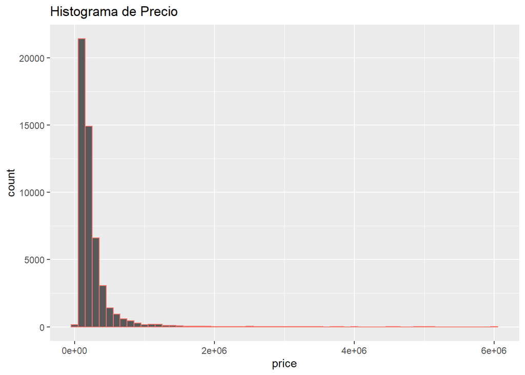

```r
ggplot(data = datos_sel2, aes(x = price, col="blue"))+
  geom_histogram(binwidth = 100000 )+
  labs(title = "Histograma de Precio")+
  theme(legend.position = 'none')
```

4b) Obtener estadisticas descriptivas para la variable precio (cuartiles, promedio, minimo y maximo) por cada tipo de propiedad.

```r
mistads2 <- function(x){
xx <-  datos_sel2[datos_sel2$property_type== x,c("price")]

                m <- round(mean(xx),2)
                q <- quantile(xx)
                n <- length(xx)
                mi <- min(xx)
                ma <- max(xx)
                return(c(n=n, cuartiles=q, media=m, minimo=mi, maximo=ma))
}


lista_tipos_prop <- unique( datos_sel2$property_type)
bases_df <- data.frame()
bases_df <- tibble(lista_tipos_prop) %>%
  mutate(resultado = purrr::map(lista_tipos_prop, mistads2))


bases_df  %>%
  kable(digits=0) %>%
  kable_styling(position = "left", full_width = F)
```

| lista_tipos_prop | resultado |
| --- | --- |
| Casa | c(n = 2028, `cuartiles.0%` = 20000, `cuartiles.25%` = 235000, `cuartiles.50%` = 335000, `cuartiles.75%` = 490000, `cuartiles.100%` = 5e+06, media = 434188.75, minimo = 20000, maximo = 5e+06) |
| Departamento | c(n = 44268, `cuartiles.0%` = 6000, `cuartiles.25%` = 115000, `cuartiles.50%` = 164000, `cuartiles.75%` = 260000, `cuartiles.100%` = 6e+06, media = 246855.73, minimo = 6000, maximo = 6e+06) |
| PH | c(n = 4914, `cuartiles.0%` = 32000, `cuartiles.25%` = 137000, `cuartiles.50%` = 190000, `cuartiles.75%` = 270000, `cuartiles.100%` = 1500000, media = 218747.43, minimo = 32000, maximo = 1500000) |

3. Realizar un grafico de boxplot de la variable precio por tipo de propiedad

Se nota en promedio las casas son mas caras que los demás y tienen más varianza. El precio de los departamentos es parecido a los PH, aunque con más valores fuera del rango intercuartil.

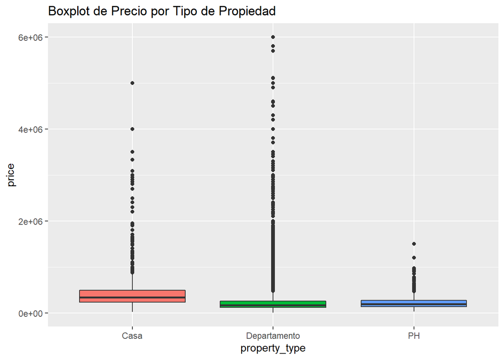

```r
ggplot(data = datos_sel2, aes(x= property_type,y = price, group= property_type, fill= property_type))+
  geom_boxplot()+
  labs(title = "Boxplot de Precio por Tipo de Propiedad")+
  theme(legend.position = 'none')+
  scale_y_continuous(limits = c(0, 6000000))
```

4. Realizar un correlagrama usando `GGAlly`

   Se nota alta correlación positiva de:

   surface_total con surface_covered,

   price con bathrooms y rooms,

   rooms con bathrooms

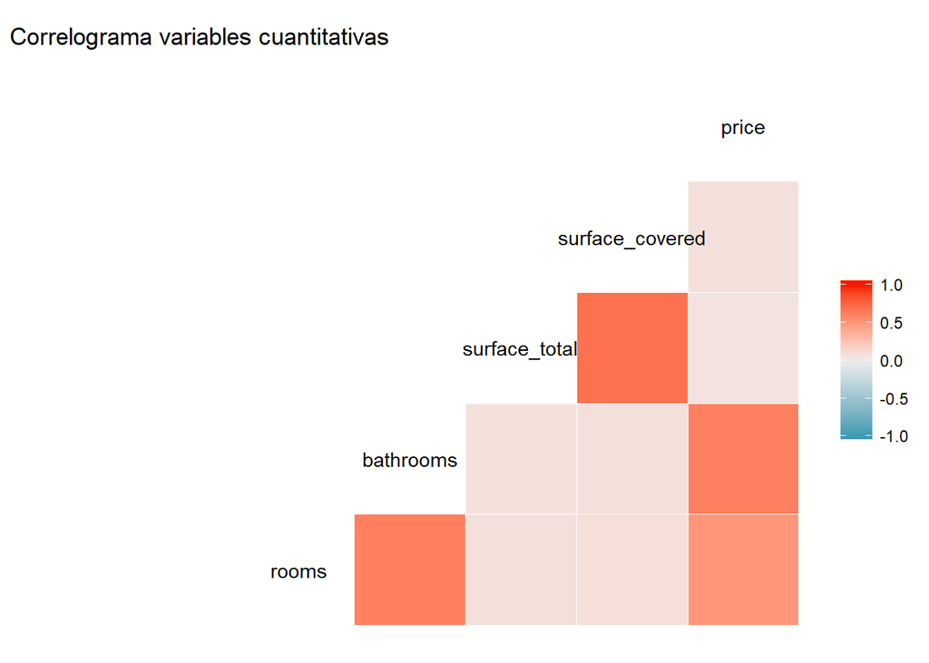

```r
ggcorr(datos_sel2, layout.exp = 2) + labs(title='Correlograma variables cuantitativas')
```

5. Outliers
   1. Eliminar los outliers de la variable **precio** con algún criterio que elijan: puede ser por valores de corte, eliminar el x% a izquierda y derecha,etc.

   Elijo calcular una variable nueva **precio_por_metro** para ayudarme a identificar propiedades que tengan valores incorrectos y que puedan ser outliers candidatos a eliminar. Es real que hay propiedades caras porque son muy grandes o por la categoría. Pero dentro de lo que conocemos en Capital,los valores lógicos llegan hasta un cierto valor. Lo mismo en el extremo inferior, no hay propiedades que valgan menos que cierto valor por metro cuadrado.

   Para observar, hago un histograma de los que tienen precio_por_metro superior a 7000 y otro para inferior a 400

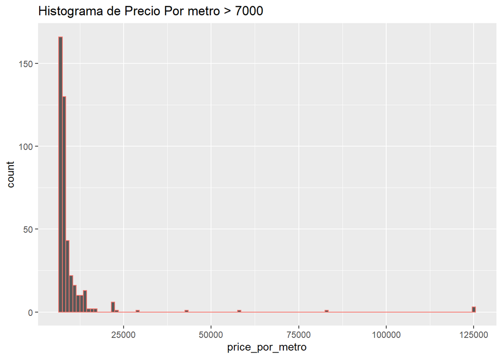

```r
# calculo variable precio_por_metro

datos_sel3 <- datos_sel2 %>% mutate( price_por_metro = price / surface_total)

# me fijo cuántos tienen valores extremos
ggplot(data = datos_sel3[datos_sel3$price_por_metro> 7000,], aes(x = price_por_metro, col="blue"))+
  geom_histogram(binwidth = 1000 )+
  labs(title = "Histograma de Precio Por metro > 7000")+
  theme(legend.position = 'none')
```

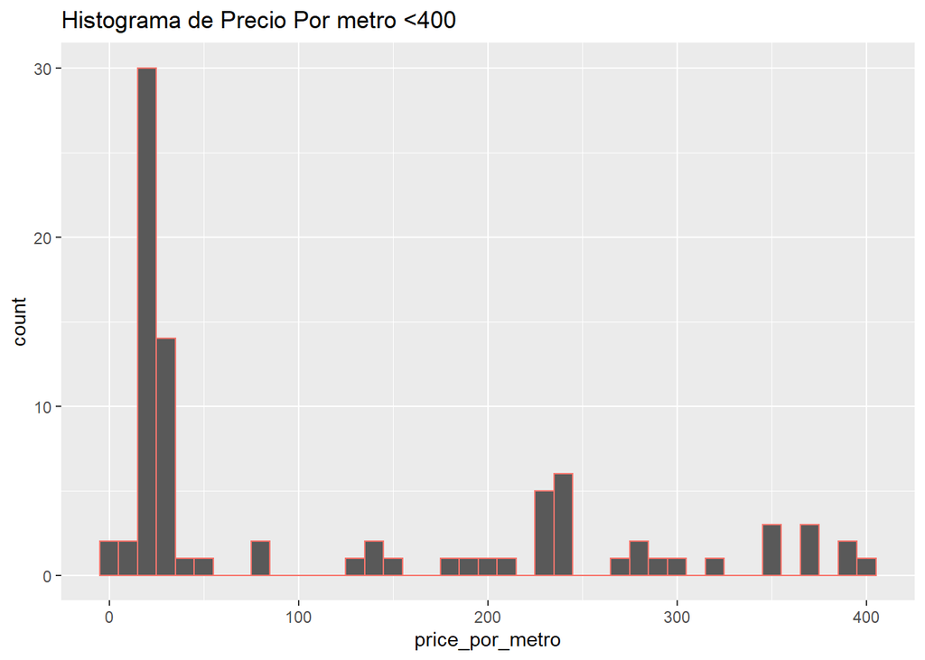

```r
ggplot(data = datos_sel3[datos_sel3$price_por_metro< 400,], aes(x = price_por_metro, col="blue"))+
  geom_histogram(binwidth = 10 )+
  labs(title = "Histograma de Precio Por metro <400")+
  theme(legend.position = 'none')
```

La cantidad de outliers que seleccioné resulta 522, el 1% aproximadamente del dataset

```r
datos_sel3$outlier <- (datos_sel3$price_por_metro < 300 | datos_sel3$price <30000 | datos_sel3$price_por_metro >  7000)


datos_sel3 %>%   group_by(outlier) %>% summarise(n())
```

| outlier | n() |
| --- | --- |
| FALSE | 50688 |
| TRUE | 522 |

6. Analisis exploratorios (III) Repetir los 4 análisis exploratorios realizados en el punto 4 y realizar unos breves comentarios sobre los cambios que encontraron
1. Obtener estadisticas descriptivas para la variable precio (cuartiles, promedio, minimo y maximo) y realizar un histograma de la variable

### Me quedo con los que no marqué como outlier.

Al remover outliers bajó un poco el valor del precio promedio.

```r
datos_sel4 <- datos_sel3 %>% filter(!outlier)

mistads <- function(x){
                m <- mean(x)
                q <- quantile(x)
                n <- length(x)
                mi <- min(x)
                ma <- max(x)
                return(c(n=n, cuartiles=q, media=m, minimo=mi, maximo=ma))
}

resultados <- mistads(datos_sel4$price)

resultados  %>%
  kable(col.names = "Precio USD",digits=0) %>%
  kable_styling(position = "left", full_width = F)
```

|  | Precio USD |
| --- | --- |
| n | 50688 |
| cuartiles.0% | 30000 |
| cuartiles.25% | 118125 |
| cuartiles.50% | 169000 |
| cuartiles.75% | 270000 |
| cuartiles.100% | 5700000 |
| media | 239692 |
| minimo | 30000 |
| maximo | 5700000 |

Histograma de variable Precio

Observo que no varió mucho el histograma, ya que no fue muy drástica la quita de outliers

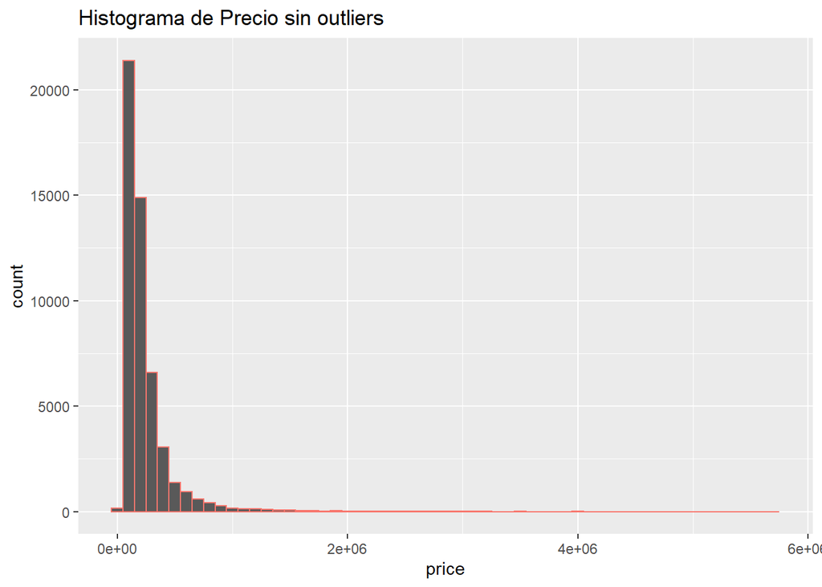

```r
ggplot(data = datos_sel4, aes(x = price, col="blue"))+
  geom_histogram(binwidth = 100000 )+
  labs(title = "Histograma de Precio sin outliers")+
  theme(legend.position = 'none')
```

6b) Obtener estadisticas descriptivas para la variable precio (cuartiles, promedio, minimo y maximo) por cada tipo de propiedad.

Se mantienen parecidas a los valores obtenidos anteriormente

```r
mistads4 <- function(x){
xx <-  datos_sel4[datos_sel4$property_type== x,c("price")]

                m <- round(mean(xx),2)
                q <- quantile(xx)
                n <- length(xx)
                mi <- min(xx)
                ma <- max(xx)
                return(c(n=n, cuartiles=q, media=m, minimo=mi, maximo=ma))
}


lista_tipos_prop <- unique( datos_sel4$property_type)
bases_df <- data.frame()
bases_df <- tibble(lista_tipos_prop) %>%
  mutate(resultado = purrr::map(lista_tipos_prop, mistads4))


bases_df  %>%
  kable(digits=0) %>%
  kable_styling(position = "left", full_width = F)
```

| lista_tipos_prop | resultado |
| --- | --- |
| Casa | c(n = 2016, `cuartiles.0%` = 62000, `cuartiles.25%` = 235000, `cuartiles.50%` = 335000, `cuartiles.75%` = 490000, `cuartiles.100%` = 5e+06, media = 430253.47, minimo = 62000, maximo = 5e+06) |
| Departamento | c(n = 43771, `cuartiles.0%` = 30000, `cuartiles.25%` = 115000, `cuartiles.50%` = 162000, `cuartiles.75%` = 259000, `cuartiles.100%` = 5700000, media = 233252.94, minimo = 30000, maximo = 5700000) |
| PH | c(n = 4901, `cuartiles.0%` = 32000, `cuartiles.25%` = 137000, `cuartiles.50%` = 190000, `cuartiles.75%` = 272000, `cuartiles.100%` = 1500000, media = 218816.77, minimo = 32000, maximo = 1500000) |

6c) Realizar boxplot de precio por tipo de propiedad

Se observa parecido al bloxplot anterior

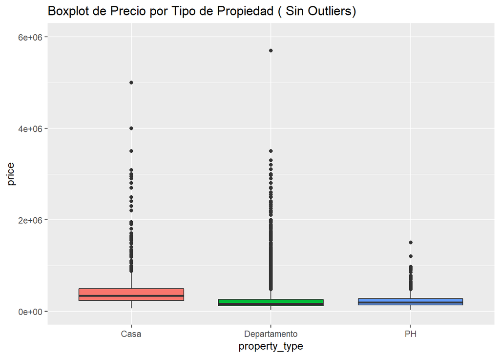

```r
ggplot(data = datos_sel4, aes(x= property_type,y = price, group= property_type, fill= property_type))+
  geom_boxplot()+
  labs(title = "Boxplot de Precio por Tipo de Propiedad ( Sin Outliers) ")+
  theme(legend.position = 'none')+
  scale_y_continuous(limits = c(0, 6000000))
```

6d) Realizar correlagrama usando Ggally

Ahora aparece alta correlación positiva de precio con superficie, sobre todo con surface_total, que antes no existía. Y en general, alta correlación entre todas las variables.

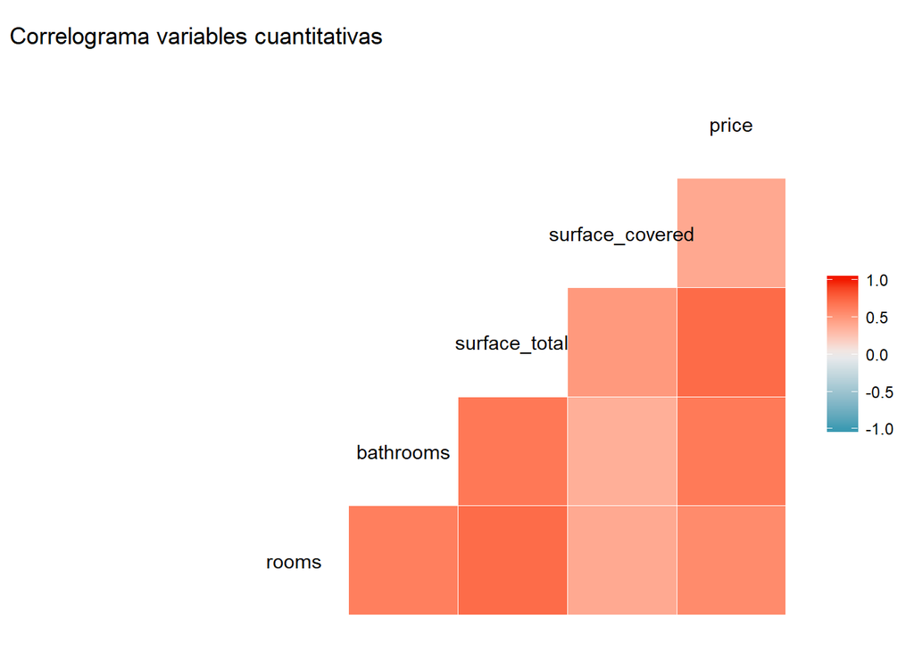

```r
datos_sel4_aux <- datos_sel4 %>% select(-price_por_metro)
ggcorr(datos_sel4_aux, layout.exp = 2) + labs(title='Correlograma variables cuantitativas')
```

7. Realizar modelo de regresion lineal que explique el precio en funcion de las rooms y otro en funcion de la superficie total

Grafico precio en función de rooms, y precio en función de surface_total

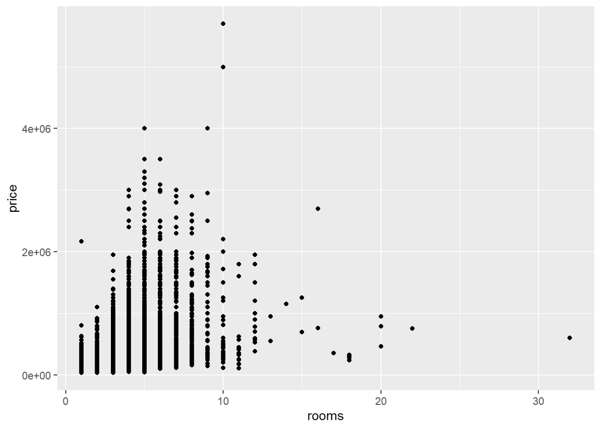

```r
ggplot(datos_sel4, aes(rooms, price) ) +
  geom_point()
```

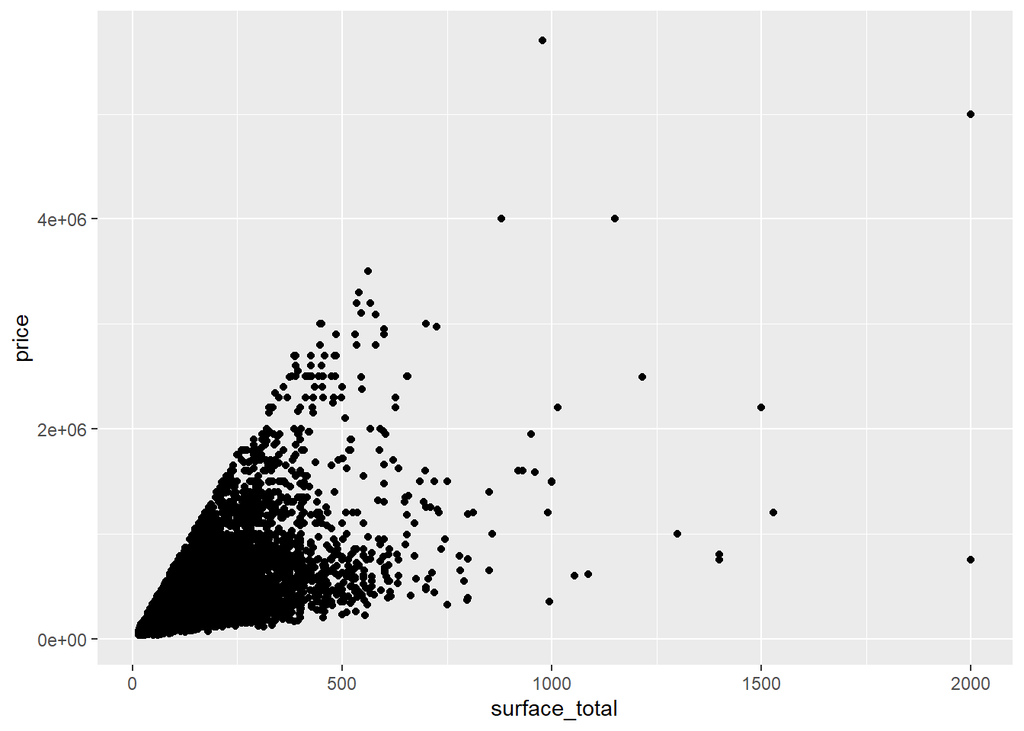

```r
ggplot(datos_sel4, aes(surface_total, price) ) +
  geom_point()
```

Hago los modelos y muestro los coeficientes

```r
rooms_mod <- lm(price ~ rooms, data = datos_sel4)
coef(rooms_mod)
```

```
## (Intercept)       rooms
##   -30873.38    96812.34
```

```r
surface_mod <- lm(price ~ surface_total, data = datos_sel4)
coef(surface_mod)
```

```
##   (Intercept) surface_total
##     43770.290      2161.451
```

### Interpretación de los parametros

- Modelo Precio en función de rooms

$$Precio = -30873.38 + 96812.34 * rooms$$

-30873.38 : es la ordenada al origen, representa el valor de una propiedad con 0 habitaciones, lo cual no tiene sentido en este dataset

96812.34 : es la pendiente de la recta. Indica cuánto aumenta la variable precio por cada unidad que aumenta la variable rooms

- Modelo Precio en función de Surface_total

$$Precio = 43770.29 + 2161.451 * surface\_total$$

43770,29 : es la ordenada al origen, representa el valor de una propiedad con 0 metros. En este caso se puede interpretar como un precio base del cual arranca el precio de cualquier propiedad

2161,451 : es la pendiente de la recta. Indica cuánto aumenta la variable precio por cada metro que aumenta la variable surface_total

Ahora obtengo el summary de cada modelo

```r
summary(rooms_mod)
```

```
##
## Call:
## lm(formula = price ~ rooms, data = datos_sel4)
##
## Residuals:
##      Min       1Q   Median       3Q      Max
## -2467122   -85564   -24751    38624  4762750
##
## Coefficients:
##             Estimate Std. Error t value Pr(>|t|)
## (Intercept) -30873.4     1989.1  -15.52   <2e-16 ***
## rooms        96812.3      637.1  151.95   <2e-16 ***
## ---
## Signif. codes:  0 '***' 0.001 '**' 0.01 '*' 0.05 '.' 0.1 ' ' 1
##
## Residual standard error: 199600 on 50686 degrees of freedom
## Multiple R-squared:  0.313,  Adjusted R-squared:  0.3129
## F-statistic: 2.309e+04 on 1 and 50686 DF,  p-value: < 2.2e-16
```

```r
summary(surface_mod)
```

```
##
## Call:
## lm(formula = price ~ surface_total, data = datos_sel4)
##
## Residuals:
##      Min       1Q   Median       3Q      Max
## -3616672   -44303   -17390    21157  3542331
##
## Coefficients:
##                Estimate Std. Error t value Pr(>|t|)
## (Intercept)   43770.290   1114.282   39.28   <2e-16 ***
## surface_total  2161.451      9.193  235.11   <2e-16 ***
## ---
## Signif. codes:  0 '***' 0.001 '**' 0.01 '*' 0.05 '.' 0.1 ' ' 1
##
## Residual standard error: 166500 on 50686 degrees of freedom
## Multiple R-squared:  0.5217, Adjusted R-squared:  0.5216
## F-statistic: 5.528e+04 on 1 and 50686 DF,  p-value: < 2.2e-16
```

Grafico los puntos, y la recta del modelo

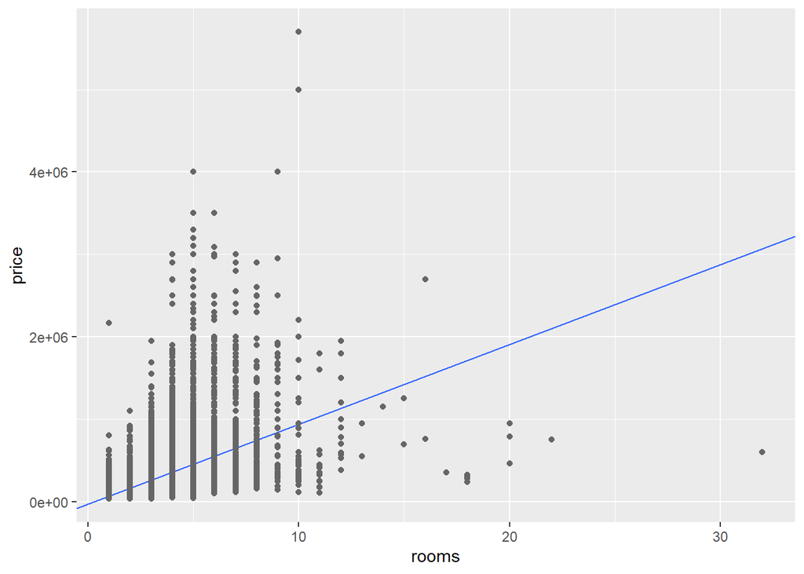

```r
##rooms
ggplot(datos_sel4, aes(rooms, price)) +
   geom_abline(intercept = -30873.38, slope = 96812.34, colour = "#3366FF") +
  geom_point(colour = "grey40")
```

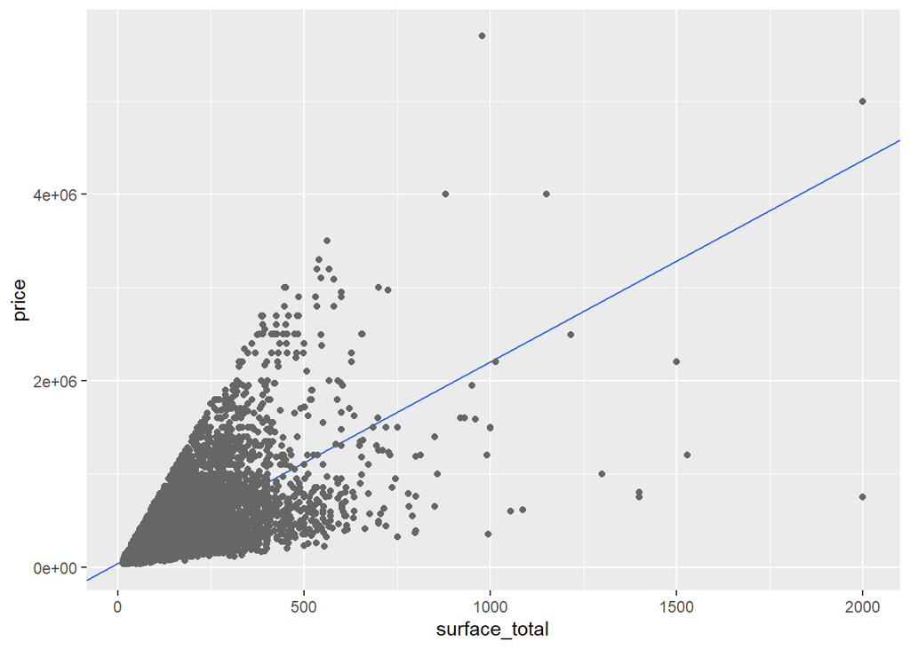

```r
ggplot(datos_sel4, aes(surface_total, price)) +
   geom_abline(intercept = 43770.29 , slope =  2161.451 , colour = "#3366FF") +
  geom_point(colour = "grey40")
```

### Conclusiones

Dado que los p-valores son muy chicos, ambos modelos son estadisticamente significativos.

El modelo que elegiría es el de precio en función de la superficie, porque tiene menor Residual standard error (166500) y mayor R-squared (52%), lo que significa que tiene menos residuos y que la variabilidad observada del precio está mejor explicada en función de la surface_total que en función de la cantidad de habitaciones.